# Quick Start Guide

## Introduction

This guide is intended to assist users in the initial setup and demonstration of a CC3220 Azure application using the CC3220 Azure IoT Plugin. The guide explains how to configure the boards, compile the software artifacts, program the CC3220 device, set up your Azure account and run an Azure application.

## Hardware Requirements

- [TI CC3220SF (Secure Flash)](http://www.ti.com/tool/cc3220sf-launchxl) and/or [TI CC3220S (Secure)](http://www.ti.com/tool/cc3220s-launchxl) LaunchPad

## Software Requirements

- [SimpleLink CC3220 SDK 1.40](http://www.ti.com/tool/simplelink-cc3220-sdk)
- A computer running a supported operating system listed in the Release Notes
- [CCS 7.2.0 or above](http://processors.wiki.ti.com/index.php/Download_CCS)

## Installing CC3220 Azure IoT Plugin in CCS

1. Download and open the CC3220 Azure IoT Plugin Installer (replace x’s with version number):
   - Windows: azure_cc3220_x_xx_xx_xx.exe
   - Linux: azure_cc3220_x_xx_xx_xx.run
2. Select an installation directory. This will be referred to as `AZURE_INSTALL_DIR` in the rest of this document. It’s recommended that you install it in your CCS installation directory (default c:/ti) so it can be discovered automatically.
3. Click Next > and finish the installation
4. Open CCS (close and re-open if already running) and you should see the Install Discovered Products window
5. Select the CC3220 Azure IoT Plugin and click Install

## Hardware Setup

### Jumper settings

The SOP[2…0] jumpers are used to set different flash programming modes/states.

1. SOP[2…0] mode ‘100’ is used for programming the serial flash with the application binary and/or the service pack. After flashing, the board should be reset and the mode set to ‘000’ (no jumpers in place) to run/execute the contents of flash
2. SOP[2…0] mode ‘010’ is the flash and execute mode which is similar to the ‘100’ mode except that after flashing, the contents of flash are executed immediately without having to reset or remove all jumpers. This mode is also used when using the CCS to connect to the device for loading and debugging

[figure not shown]

### Setting up a serial terminal

1. Plug the CC3220 Launchpad into a USB port on your PC.
2. Open a serial session to the appropriate COM port with the following settings:

   ```
   Baudrate:     115200
   Data bits:       8
   Stop bits:       1
   Parity:       None
   Flow Control: None
   ```

3. The output of the examples will be displayed in the terminal.

## Azure IoT Developer Setup

In order to run the example applications, it is necessary to complete the following steps:

1. [Setup your IoT hub](https://catalog.azureiotsuite.com/docs?title=Azure/azure-iot-device-ecosystem/setup_iothub)
2. [Provision your device and get its credentials](https://catalog.azureiotsuite.com/docs?title=Azure/azure-iot-device-ecosystem/manage_iot_hub)

## Building and running Examples in CCS

Several examples are provided in the CC3220 Plugin and can be found in the `examples/` subdirectory. These steps refer to the `simplesample_http` application for the CC3220SF device, but the same procedure applies to the CC3220S and to other examples, as well.

1. It is assumed that the CC3220 SDK has already been installed in a directory we will refer to as `CC32XX_SDK_INSTALL_DIR`. You should install it if you have not already done so, as the CC3220 Azure IoT Plugin depends on the CC3220 SDK.
2. Open Code Composer Studio.
3. In CCS, import the `simplesample_http` by first selecting File > Import…
4. In the Import window, select C/C++ > CCS Projects and hit the Next button
5. In the Import CCS Eclipse Projects window, hit the browse button to browse to the location corresponding to `AZURE_INSTALL_DIR\examples\rtos\CC3220SF_LAUNCHXL\azure\simplesample_http`. Select the checkbox next to the `simplesample_http` for tirtos for CCS and hit the Finish button.

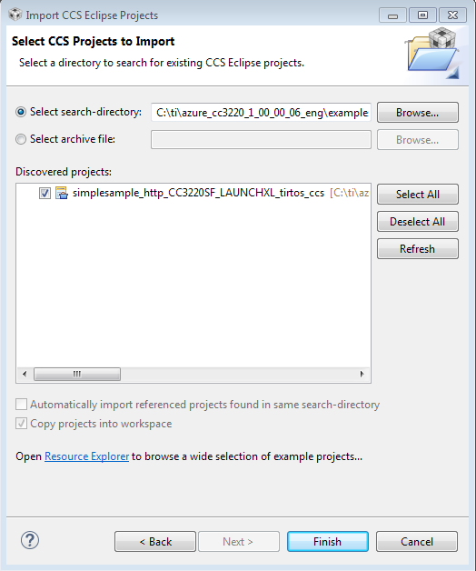

6. Update the example to use your Azure connection string and WiFi Access Point information, as specified in the section Example Pre-Build Steps
7. Two projects should appear in the Project Explorer tab in CCS: one for the `simplesample_http` example itself (ie. simplesample_http_CC3220SF_LAUNCHXL_tirtos_ccs), and the other is a project corresponding to the OS chosen (e.g. azure_cc32xx_tirtos_builds_CC3220SF_LAUNCHXL_release_ccs). If tirtos is your OS, you can simply right-click on the `simplesample_http` project, and select Build Project to build.

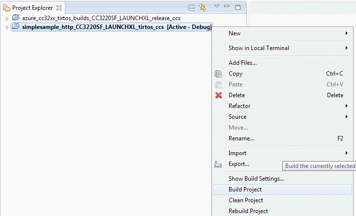

### Setting Up Code Composer Studio Before Running The Examples

1. In Code Composer Studio, open the CCS Debug Perspective - Windows menu > Perspective > Open Perspective > CCS Debug
2. Open the Target Configurations View - Windows menu > Show View > Target Configurations
3. Right-click on User Defined. Select New Target Configuration.
4. Use `CC3220.ccxml` as “File name”. Hit Finish.
5. In the Basic window, select “Texas Instruments XDS110 USB Debug Probe” as the “Connection”, and then type “CC3220” in the “Board or Device” text field. Check the box next to “CC3220SF” or “CC3220S” (depending on your launchpad). Hit Save.
6. Right-click “CC3220.ccxml” in the Target Configurations View. Hit Launch Selected Configuration.
7. Under the Debug View, right-click on “Texas Instruments XDS110 USB Debug Probe_0/Cortex_M4_0”. Select “Connect Target”.

### Running an Example in CCS

1. Optional: If you have not yet run any applications on your CC3220 since powering it on, then skip to step 2. Otherwise, if you have recently run an application on the CC3220 since powering it on, it is necessary to reset the board. Disconnect and reconnect the CC3220’s USB cable in order to power cycle the hardware, and then reconnect in CCS. For best results, it is recommended to do this before loading and running an application every time, in order to reset the CC3220’s network processor.
2. Select Run menu > Load > Load Program…, and browse to the file `simplesample_http_CC3220SF_LAUNCHXL_tirtos_ccs.out`, found in your project. Hit OK. This will load the program onto the board. (The same procedure applies to other examples by substituting `simplesample_http` with the name of the example you are working with)
3. Run the application by pressing F8. The output will appear in your serial terminal session:

   ```
   Starting the simplesample_http example
   CC3220 has connected to AP and acquired an IP address.
   IP Address: 192.168.1.128
   Current time: Wed May 31 22:08:22 2017

   Flashing certificate file ...successfully wrote file /cert/ms.der to flash
   Info: IoT Hub SDK for C, version 1.1.15
   IoTHubClient accepted the message for delivery
   Message Id: 1 Received.
   Result Call Back Called! Result is: IOTHUB_CLIENT_CONFIRMATION_OK
   ```

### Viewing data from the cloud

You can view the data that has been received on the cloud side in various ways, for example using the Device Explorer or the iothub-explorer from Microsoft, or creating an Azure Function App on the Azure portal itself. Please refer to [online documentation](https://docs.microsoft.com/en-us/azure/iot-hub/iot-hub-get-started) from Microsoft to learn about the various ways to interact with the IoT Hub.

## Building with makefiles

To build the `simplesample_http` application on the command-line using the provided makefile:

1. Update the `imports.mak` file in the `<AZURE_INSTALL_DIR>` root folder with the appropriate path(s). This file relies on the settings in the `imports.mak` file of the CC3220 SDK, so please ensure you have updated the latter with the appropriate paths as well if you have not done so previously.
2. Navigate to the OS directory corresponding to your OS of choice. For example, `<AZURE_INSTALL_DIR>/kernel/tirtos/builds/CC3220SF_LAUNCHXL/release/ccs` for tirtos.
3. Run ‘make’ to build the OS. If you develop on a Windows machine and do not have the ‘make’ utility, you can alternatively run ‘gmake’ from your TI XDCTOOLS installation (e.g. ‘C:\ti\xdctools_3_50_01_12_core\gmake.exe’). Normally XDCTOOLS are installed along with the CC3220 SDK, but if you need to download it, it is available [here](http://software-dl.ti.com/dsps/dsps_public_sw/sdo_sb/targetcontent/rtsc/index.html)
4. Update the example to use your Azure connection string and WiFi Access Point information, as specified in the section Example Pre-Build Steps
5. Navigate to the example folder specific to your OS `<AZURE_INSTALL_DIR>/examples/rtos/CC3220SF_LAUNCHXL/azure/simplesample_http/tirtos/ccs`
6. To build, run ‘make’ to generate `simplesample_http.out`
7. You can load and debug the generated `simplesample_http.out` in CCS
8. The Example output is displayed in the serial terminal, as shown here.

## Example Pre-Build Steps

Before building a specific application, you must complete the following steps in order to successfully connect to Azure (these steps refer to the `simplesample_http` application for the CC3220SF device, but the same procedure applies to other examples as well):

### Update the Azure connection string

Open the `simplesample_http.c` file from the directory `<AZURE_INSTALL_DIR>\azure-iot-sdk-c\serializer\samples\simplesample_http` in a text editor and replace the value of the “connectionString” variable with the device connection string you noted when you registered your device with the IoT hub. (Other examples similarly have a source file named `<example_name>.c` or `NetMgr.c` where the connection string can be set.)

### Flash the root certificate

> Note: In the examples, the root CA certificate - “Baltimore CyberTrust Root” is flashed to CC3220 Launchpad to the location `/cert/ms.der`. This location is referenced in `<AZURE_INSTALL_DIR>\source\third_party\azure-iot-sdk-c\c-utility\adapters\httpapi_tirtos.c` and `<AZURE_INSTALL_DIR>\source\third_party\azure-iot-sdk-c\c-utility\adapters\tlsio_sl.c`, and is used by SimpleLink TLS stack.

Here’s why you need the Baltimore root CA - it’s the root CA for `*.azure-devices.net`, the IoT Hub endpoint and it’s the only way for the tiny CC3220 to verify the chain of trust:

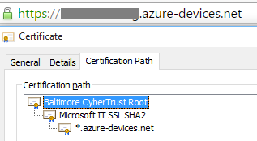

The default behavior of the example is to automatically write the certificate to flash if it does not exist. This prevents the file from being written unnecessarily to the file system each time the program is run. If you wish to override this behavior, or if you wish to use a new certificate file, you can force the certificate to be flashed by passing “-DOVERWRITE_CERTS” to the compiler in the makefile. Otherwise it is best to not change anything here.

### Update The Example With Your Wi-Fi Access Point Information

Open the file `wificonfig.h`, found in the `simplesample_http` project. Search for “USER STEP” and update the Wi-Fi SSID and SECURITY_KEY macros.

# Other Info

More CCS project information can be found [here](http://processors.wiki.ti.com/index.php/Portable%20Projects) and [here](http://processors.wiki.ti.com/index.php/Include%20paths%20and%20options).